# Exercise Prediction

## Introduction

The document describes apporoach to buil a predictive model for the Weight Lifting Exercises Dataset.The goal is to fit a predictive model to the provided data in order to predict the kind of eightlifting that was performed. It turns out that we can fit calssification tree and random forest model which predict on sample data.

## Import the Data

First we will load all the libraries required

```r
library(caret)
library(rattle)
```

```r
library(rpart.plot)
library(randomForest)
#Load the the data
training <- read.csv("./Data/pml-training.csv", na.strings = c("NA", ""))
testing<-read.csv("./Data/pml-testing.csv",na.strings = c("NA",""))

dim(training)
```

```
## [1] 19622   160
```

```r
dim(testing)
```

```
## [1]  20 160
```

About data :-Training dataset has 19622 rows and 160 variables.Testing dataset has 20 rows and 160 variables.Here we will try to predict the outcome of ‘calsse’ variable in the training set.

```r
names(training)
```

```
##   [1] "X"                        "user_name"
##   [3] "raw_timestamp_part_1"     "raw_timestamp_part_2"
##   [5] "cvtd_timestamp"           "new_window"
##   [7] "num_window"               "roll_belt"
##   [9] "pitch_belt"               "yaw_belt"
##  [11] "total_accel_belt"         "kurtosis_roll_belt"
##  [13] "kurtosis_picth_belt"      "kurtosis_yaw_belt"
##  [15] "skewness_roll_belt"       "skewness_roll_belt.1"
##  [17] "skewness_yaw_belt"        "max_roll_belt"
##  [19] "max_picth_belt"           "max_yaw_belt"
##  [21] "min_roll_belt"            "min_pitch_belt"
##  [23] "min_yaw_belt"             "amplitude_roll_belt"
##  [25] "amplitude_pitch_belt"     "amplitude_yaw_belt"
##  [27] "var_total_accel_belt"     "avg_roll_belt"
##  [29] "stddev_roll_belt"         "var_roll_belt"
```

[output cut: 65 more lines]

### Data Cleaning

The training dataset has many missing values.We will delete those variables Also, forst 7 variables do not seem to have any impact on prediction. So we will delete them.We do the same for testing dataset as well.

```r
training<-training[,colSums(is.na(training))==0]
testing<-testing[,colSums(is.na(testing))==0]

#Remove first 7 variables
trainigData<-training[,-c(1:7)]
testingData<-testing[,-c(1:7)]

dim(trainigData)
```

```
## [1] 19622    53
```

```r
dim(testingData)
```

```
## [1] 20 53
```

So,now we have 19622 observations and 53 variables in training dataset.Testing dataset has 20 observations and 53 variables.

### Data splitting for Validation

Split cleaned data to 70-30% for training and validation

```r
set.seed(8000)
inTrain<-createDataPartition(trainigData$classe,p=0.7,list=FALSE)
train<-trainigData[inTrain,]
valid<-trainigData[-inTrain,]
```

## Prediction

We use Classification trees and Random forests to predict the outcome.

### Classification Trees

We will not be transforming the data as we are using classification algortihms.

```r
fit1<-rpart(classe ~ .,data=train,method = "class")
```

Plot the graph

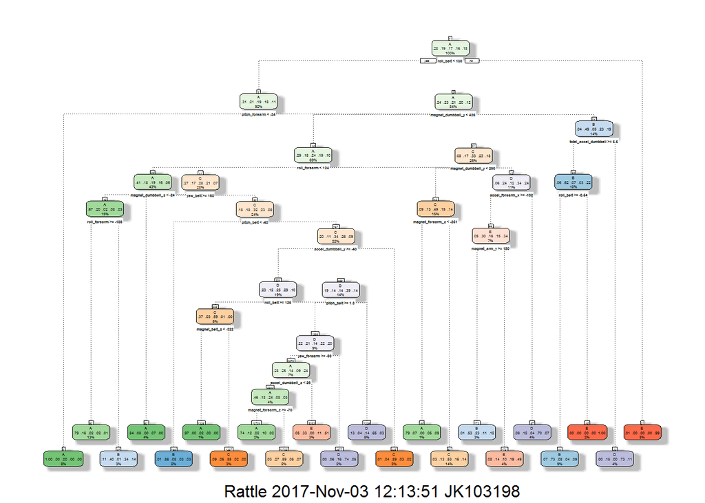

```r
fancyRpartPlot(fit1)
```

### Predict the outcome using validation dataset

```r
predict1<-predict(fit1,valid,type = "class")

#Confusion matrix for accuracy
(conf_rpart<-confusionMatrix(predict1,valid$classe))
```

```
## Confusion Matrix and Statistics
##
##           Reference
## Prediction    A    B    C    D    E
##          A 1486  172   21   55   18
##          B   58  597   79   84  100
##          C   53  173  834  143  146
##          D   45   80   64  618   56
##          E   32  117   28   64  762
##
## Overall Statistics
##
##                Accuracy : 0.7302
##                  95% CI : (0.7186, 0.7415)
##     No Information Rate : 0.2845
##     P-Value [Acc > NIR] : < 2.2e-16
##
##                   Kappa : 0.6583
##  Mcnemar's Test P-Value : < 2.2e-16
##
## Statistics by Class:
##
##                      Class: A Class: B Class: C Class: D Class: E
## Sensitivity            0.8877   0.5241   0.8129   0.6411   0.7043
## Specificity            0.9368   0.9324   0.8940   0.9502   0.9498
## Pos Pred Value         0.8482   0.6503   0.6182   0.7161   0.7597
## Neg Pred Value         0.9545   0.8909   0.9577   0.9311   0.9345
## Prevalence             0.2845   0.1935   0.1743   0.1638   0.1839
## Detection Rate         0.2525   0.1014   0.1417   0.1050   0.1295
## Detection Prevalence   0.2977   0.1560   0.2292   0.1466   0.1704
## Balanced Accuracy      0.9123   0.7283   0.8534   0.7956   0.8270
```

```r
#Display only Accuracy
(accuracy_rpart<-conf_rpart$overall[1])
```

```
##  Accuracy
## 0.7301614
```

From the consuiosn matrix, it is found that accuracy rate is 0.73.

### Random Forests

```r
fit2<-randomForest(classe ~ .,data=train,method="class")
predict2<-predict(fit2,valid,type = "class")

#Confusion matrix for accuracy
(conf_rfor<-confusionMatrix(predict2,valid$classe))
```

```
## Confusion Matrix and Statistics
##
##           Reference
## Prediction    A    B    C    D    E
##          A 1674    1    0    0    0
##          B    0 1134    4    0    0
##          C    0    4 1020   15    0
##          D    0    0    2  948    5
##          E    0    0    0    1 1077
##
## Overall Statistics
##
##                Accuracy : 0.9946
##                  95% CI : (0.9923, 0.9963)
##     No Information Rate : 0.2845
##     P-Value [Acc > NIR] : < 2.2e-16
##
##                   Kappa : 0.9931
##  Mcnemar's Test P-Value : NA
##
## Statistics by Class:
##
##                      Class: A Class: B Class: C Class: D Class: E
## Sensitivity            1.0000   0.9956   0.9942   0.9834   0.9954
## Specificity            0.9998   0.9992   0.9961   0.9986   0.9998
## Pos Pred Value         0.9994   0.9965   0.9817   0.9927   0.9991
## Neg Pred Value         1.0000   0.9989   0.9988   0.9968   0.9990
## Prevalence             0.2845   0.1935   0.1743   0.1638   0.1839
## Detection Rate         0.2845   0.1927   0.1733   0.1611   0.1830
## Detection Prevalence   0.2846   0.1934   0.1766   0.1623   0.1832
## Balanced Accuracy      0.9999   0.9974   0.9951   0.9910   0.9976
```

```r
#Display only Accuracy
(accuracy_rpart<-conf_rfor$overall[1])
```

```
##  Accuracy
## 0.9945624
```

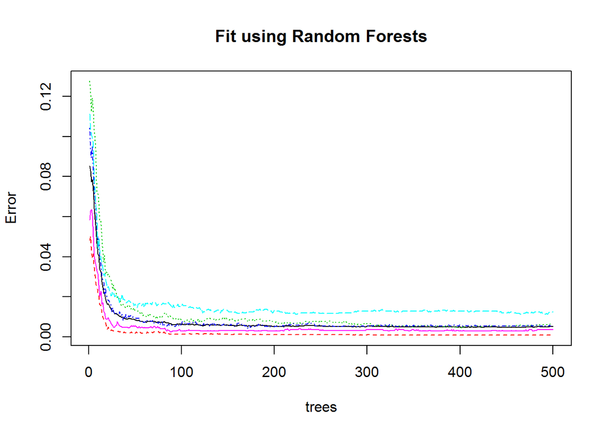

```r
#plot fit
plot(fit2,main = "Fit using Random Forests")
```

From the consuiosn matrix, it is found that accuracy rate is *0.99.This model is more accurate.*

### Apply prediction model to 20 test cases

```r
predTesting<-predict(fit2,testingData)
predTesting
```

```
##  1  2  3  4  5  6  7  8  9 10 11 12 13 14 15 16 17 18 19 20
##  B  A  B  A  A  E  D  B  A  A  B  C  B  A  E  E  A  B  B  B
## Levels: A B C D E
```